# Current Model Recreate

Here is a link to get back to the original website model.html

**In this page, we will recreate part of the current model**

## Current Model Breakdown

**4 major components are considered in the current model:**

- **Season:** *High, Medium, Low Demand Season* (Based on their understanding of average daily patient volume)
- **Weekday:** *Sun/Mon, Tue-Sat* (Assuming Sunday and Monday have more patients than that of the other days of week)
- **Acuities:** *Acuities1-2-3, Acuities4-5* (Industrial agreement of treating throughput: 2.15 pts/hour for acuities1-2-3, and 3.00 pts/hour for acuities4-5)
- **Historical Volume** *75th percentile* of the patient volumes for a specific hour given season, weekday and acuitites (Estimated by tradeoffs between cost and benefits)

## Scheduling Part

Currently, the initial physicians’ time schedule is made by Dr. Carstairs. The schedule is usually released 4 month prior, and is subjected to make slightly changes no latter than 2 weeks prior (but it’s hard and require negotiation).

We, in this document, will use the plan for a high demand season, Monday/Sunday as a demonstration. The schedule looks like below:

### Sample Table

|  | Zone | TimeSlot | H0 | H1 | H2 | H3 | H4 | H5 | H6 | H7 | H8 | H9 | H10 | H11 | H12 | H13 | H14 | H15 | H16 | H17 | H18 | H19 | H20 | H21 | H22 | H23 |
| --- | --- | --- | --- | --- | --- | --- | --- | --- | --- | --- | --- | --- | --- | --- | --- | --- | --- | --- | --- | --- | --- | --- | --- | --- | --- | --- |
| 1 | Y1 | 6a-3p | 0 | 0 | 0 | 0 | 0 | 0 | 1 | 1 | 1 | 1 | 1 | 1 | 1 | 1 | 0 | 0 | 0 | 0 | 0 | 0 | 0 | 0 | 0 | 0 |
| 2 | Y2 | 7a-4p | 0 | 0 | 0 | 0 | 0 | 0 | 0 | 1 | 1 | 1 | 1 | 1 | 1 | 1 | 1 | 0 | 0 | 0 | 0 | 0 | 0 | 0 | 0 | 0 |
| 3 | Y1 | 2p-11p | 0 | 0 | 0 | 0 | 0 | 0 | 0 | 0 | 0 | 0 | 0 | 0 | 0 | 0 | 1 | 1 | 1 | 1 | 1 | 1 | 1 | 1 | 0 | 0 |
| 4 | Y2 | 3p-12a | 0 | 0 | 0 | 0 | 0 | 0 | 0 | 0 | 0 | 0 | 0 | 0 | 0 | 0 | 0 | 1 | 1 | 1 | 1 | 1 | 1 | 1 | 1 | 0 |
| 5 | Y1 | 10p-6a | 1 | 1 | 1 | 1 | 1 | 1 | 0 | 0 | 0 | 0 | 0 | 0 | 0 | 0 | 0 | 0 | 0 | 0 | 0 | 0 | 0 | 0 | 1 | 1 |
| 6 | Y2 | 11p-7a | 1 | 1 | 1 | 1 | 1 | 1 | 1 | 0 | 0 | 0 | 0 | 0 | 0 | 0 | 0 | 0 | 0 | 0 | 0 | 0 | 0 | 0 | 0 | 1 |
| 7 | Orange | 6a-12p | 0 | 0 | 0 | 0 | 0 | 0 | 1 | 1 | 1 | 1 | 1 | 1 | 0 | 0 | 0 | 0 | 0 | 0 | 0 | 0 | 0 | 0 | 0 | 0 |
| 8 | Orange | 12p-7p | 0 | 0 | 0 | 0 | 0 | 0 | 0 | 0 | 0 | 0 | 0 | 0 | 1 | 1 | 1 | 1 | 1 | 1 | 1 | 0 | 0 | 0 | 0 | 0 |
| 9 | Orange | 7p-2a | 1 | 1 | 0 | 0 | 0 | 0 | 0 | 0 | 0 | 0 | 0 | 0 | 0 | 0 | 0 | 0 | 0 | 0 | 0 | 1 | 1 | 1 | 1 | 1 |
| 10 | Float | 9a-3p | 0 | 0 | 0 | 0 | 0 | 0 | 0 | 0 | 0 | 1 | 1 | 1 | 1 | 1 | 1 | 1 | 0 | 0 | 0 | 0 | 0 | 0 | 0 | 0 |

|  | Zone | TimeSlow | H0 | H1 | H2 | H3 | H4 | H5 | H6 | H7 | H8 | H9 | H10 | H11 | H12 | H13 | H14 | H15 | H16 | H17 | H18 | H19 | H20 | H21 | H22 | H23 |
| --- | --- | --- | --- | --- | --- | --- | --- | --- | --- | --- | --- | --- | --- | --- | --- | --- | --- | --- | --- | --- | --- | --- | --- | --- | --- | --- |
| 1 | FT am | 9a-4p | 0 | 0 | 0 | 0 | 0 | 0 | 0 | 0 | 0 | 1 | 1 | 1 | 1 | 1 | 1 | 1 | 0 | 0 | 0 | 0 | 0 | 0 | 0 | 0 |
| 2 | FT pm | 4p-10p | 0 | 0 | 0 | 0 | 0 | 0 | 0 | 0 | 0 | 0 | 0 | 0 | 0 | 0 | 0 | 0 | 1 | 1 | 1 | 1 | 1 | 1 | 0 | 0 |
| 3 | FT ON | 9:30p-4a | 1 | 1 | 1 | 1 | 0 | 0 | 0 | 0 | 0 | 0 | 0 | 0 | 0 | 0 | 0 | 0 | 0 | 0 | 0 | 0 | 0 | 0.5 | 1 | 1 |
| 4 | P | 10a-6p | 0 | 0 | 0 | 0 | 0 | 0 | 0 | 0 | 0 | 0 | 0 | 0 | 1 | 1 | 1 | 1 | 1 | 1 | 0 | 0 | 0 | 0 | 0 | 0 |
| 5 | P | 6p-2a | 1 | 1 | 0 | 0 | 0 | 0 | 0 | 0 | 0 | 0 | 0 | 0 | 0 | 0 | 0 | 0 | 0 | 0 | 1 | 1 | 1 | 1 | 1 | 1 |
| 6 | EDS 1 | 5:30p-1:30a(weekdays) | 1 | 0.5 | 0 | 0 | 0 | 0 | 0 | 0 | 0 | 0 | 0 | 0 | 0 | 0 | 0 | 0 | 0 | 0.5 | 1 | 1 | 1 | 1 | 1 | 1 |
| 7 | EDS2 | 5p-12p | 0 | 0 | 0 | 0 | 0 | 0 | 0 | 0 | 0 | 0 | 0 | 0 | 0 | 0 | 0 | 0 | 0 | 1 | 1 | 1 | 1 | 1 | 1 | 1 |

## 75th Percentile

### Brief exploration

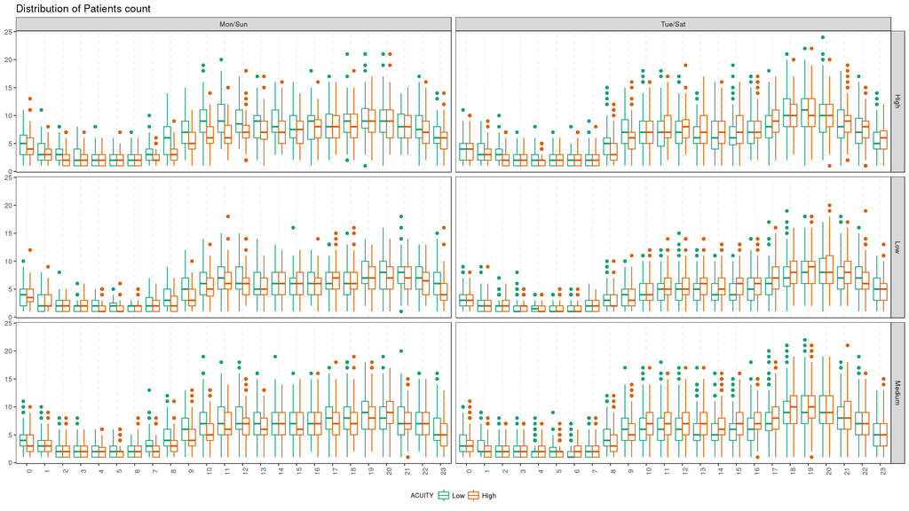

### Calculation

We use the following code to calculate the 75th percentile of patient volume by season, weekday, acuities and hour.

- `ADT_ARRIVAL_DATE`: patient arrival date
- `ADT_HOUR`: patient arrival hour
- `ACUITY`: Acuities1-2-3 are coded as ‘High’; Acuities4-5 are coded as ‘Low’
- `SEASON`: January and Feburary are coded as ‘High’; June, July and August are coded as ‘Low’; others are coded as ‘Medium’
- `WEEKDAY`: Grouped by Mon/Sun and Tue-Sat

```r
PtVolume <- data %>%
  group_by(ADT_ARRIVAL_DATE, ADT_HOUR, ACUITY, SEASON, WEEKDAY) %>%
  summarise(numPt = n()) %>%
  ungroup() %>%
  group_by(ADT_HOUR, ACUITY, SEASON, WEEKDAY) %>%
  summarise(numPercentile = quantile(numPt, serviceLevel)) %>%
  ungroup()
DT::datatable(PtVolume, options = list(autoWidth=TRUE))
```

|  | ADT_HOUR | ACUITY | SEASON | WEEKDAY | numPercentile |
| --- | --- | --- | --- | --- | --- |
| 1 | 0 | Low | High | Mon/Sun | 6.5 |
| 2 | 0 | Low | High | Tue/Sat | 5 |
| 3 | 0 | Low | Low | Mon/Sun | 5 |
| 4 | 0 | Low | Low | Tue/Sat | 4 |
| 5 | 0 | Low | Medium | Mon/Sun | 5 |
| 6 | 0 | Low | Medium | Tue/Sat | 5 |
| 7 | 0 | High | High | Mon/Sun | 6 |
| 8 | 0 | High | High | Tue/Sat | 5 |
| 9 | 0 | High | Low | Mon/Sun | 5 |
| 10 | 0 | High | Low | Tue/Sat | 4 |

[output cut: 280 more lines]

### Recreate 75th Percentile Plot

#### **Mon/Sun**

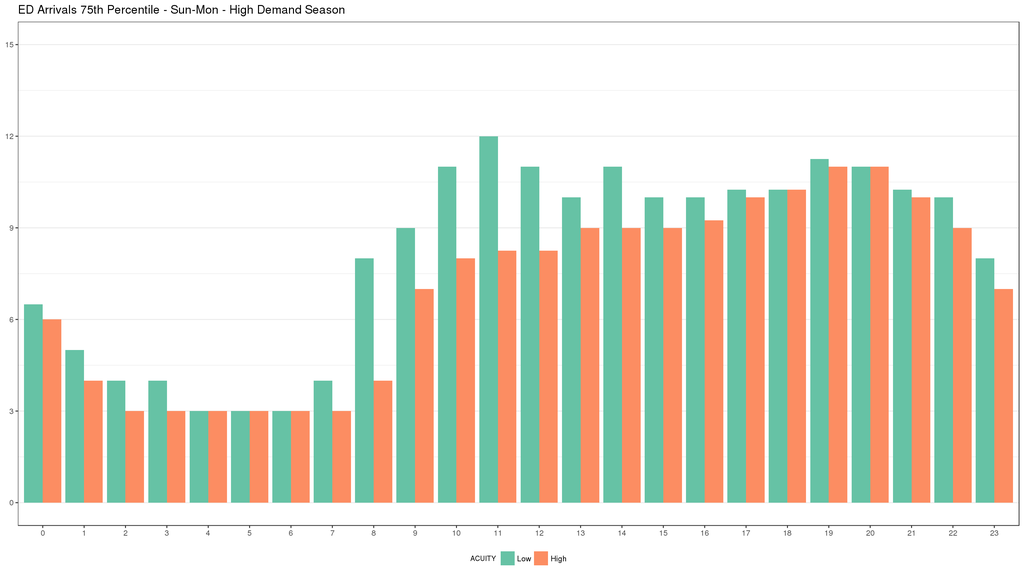

#### **Tue/Sat**

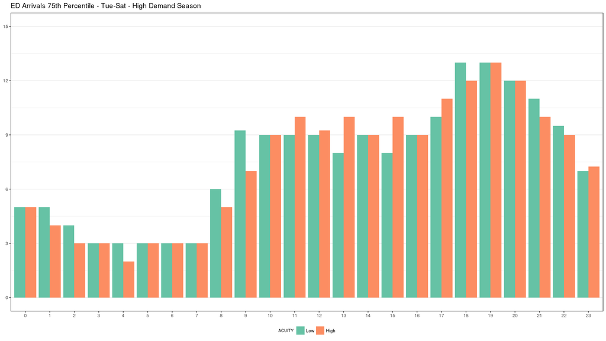

## Model Recreation

### Calculation

`smooth` represents `Patient Arrivals Estimate`, is calculated as follows:

- 24 hours are smoothed by 8 3-hour groups, (0-2, 3-5, etc.).
- Average three 75th percentile patient volumes and use the average number for all hours within each 3-hour group.

`staffingNeed` is calculated as follows:

- current hour cell denote as $h_0$,
- select the maximum `Patient Arrivals Estimate` among $h_0$, $h_{-1}$, and $h_{-2}$
- divide the maximum by the common throughput by acuities

### Code

*The following code shows the calculation step*

```r
datPassH <- PtVolume %>%
  filter(SEASON == 'High',
         ACUITY == 'High',
         WEEKDAY == 'Mon/Sun') %>%
  select(ADT_HOUR, numPercentile) %>%
  mutate(group = rep(1:8, each = 3)) %>%
  group_by(group) %>%
  mutate(smooth = mean(numPercentile)) %>%
  ungroup() %>%
  select(ADT_HOUR, smooth)
datPassH <- datPassH %>%
  mutate(staffingNeed = calcStaff(datPassH) / Pts123)

datPassL <- PtVolume %>%
  filter(SEASON == 'High',
         ACUITY == 'Low',
         WEEKDAY == 'Mon/Sun') %>%
  select(ADT_HOUR, numPercentile) %>%
  mutate(group = rep(1:8, each = 3)) %>%
  group_by(group) %>%
  mutate(smooth = mean(numPercentile)) %>%
  ungroup() %>%
  select(ADT_HOUR, smooth)
datPassL <- datPassL %>%
  mutate(staffingNeed = calcStaff(datPassL) / Pts45)
```

### Recreation

We then combine the two together to get the final presentable model

|  | hour | patientEstimateH | staffingNeedH | staffingPlanH | patientEstimateL | staffingNeedL | staffingPlanL | staffingDiffH | staffingDiffL | totalPtEst | totalStaffingNeed | totalStaffingPlan | totalStaffingDiff |
| --- | --- | --- | --- | --- | --- | --- | --- | --- | --- | --- | --- | --- | --- |
| 1 | 0 | 4.33333333333333 | 4.03100775193798 | 3 | 5.16666666666667 | 3.13888888888889 | 3 | -1.03100775193798 | -0.138888888888889 | 9.5 | 7.16989664082687 | 6 | -1.16989664082687 |
| 2 | 1 | 4.33333333333333 | 4.03100775193798 | 3 | 5.16666666666667 | 3.13888888888889 | 2.5 | -1.03100775193798 | -0.638888888888889 | 9.5 | 7.16989664082687 | 5.5 | -1.66989664082687 |
| 3 | 2 | 4.33333333333333 | 2.01550387596899 | 2 | 5.16666666666667 | 1.72222222222222 | 1 | -0.0155038759689923 | -0.722222222222222 | 9.5 | 3.73772609819121 | 3 | -0.737726098191215 |
| 4 | 3 | 3 | 2.01550387596899 | 2 | 3.33333333333333 | 1.72222222222222 | 1 | -0.0155038759689923 | -0.722222222222222 | 6.33333333333333 | 3.73772609819121 | 3 | -0.737726098191215 |
| 5 | 4 | 3 | 2.01550387596899 | 2 | 3.33333333333333 | 1.72222222222222 | 0 | -0.0155038759689923 | -1.72222222222222 | 6.33333333333333 | 3.73772609819121 | 2 | -1.73772609819121 |
| 6 | 5 | 3 | 1.3953488372093 | 2 | 3.33333333333333 | 1.11111111111111 | 0 | 0.604651162790698 | -1.11111111111111 | 6.33333333333333 | 2.50645994832041 | 2 | -0.506459948320414 |
| 7 | 6 | 3.33333333333333 | 1.55038759689922 | 3 | 5 | 1.66666666666667 | 0 | 1.44961240310078 | -1.66666666666667 | 8.33333333333333 | 3.21705426356589 | 3 | -0.217054263565892 |
| 8 | 7 | 3.33333333333333 | 1.55038759689922 | 3 | 5 | 1.66666666666667 | 0 | 1.44961240310078 | -1.66666666666667 | 8.33333333333333 | 3.21705426356589 | 3 | -0.217054263565892 |
| 9 | 8 | 3.33333333333333 | 1.55038759689922 | 3 | 5 | 1.66666666666667 | 0 | 1.44961240310078 | -1.66666666666667 | 8.33333333333333 | 3.21705426356589 | 3 | -0.217054263565892 |
| 10 | 9 | 7.75 | 3.6046511627907 | 4 | 10.6666666666667 | 3.55555555555556 | 1 | 0.395348837209302 | -2.55555555555556 | 18.4166666666667 | 7.16020671834625 | 5 | -2.16020671834625 |

[output cut: 14 more lines]

### Useful Plots

**Recreate Staffing planned vs. Staffing Est Plot**

#### High Acuities

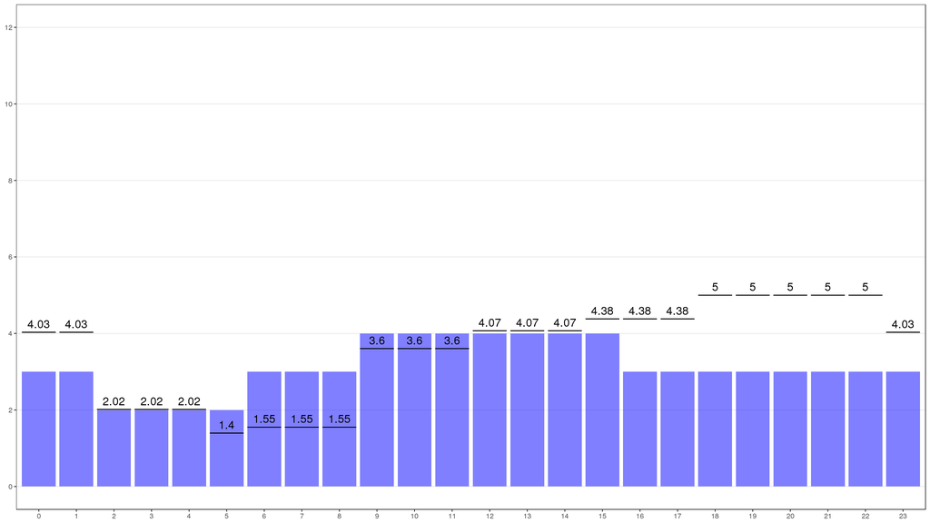

#### Low Acuities

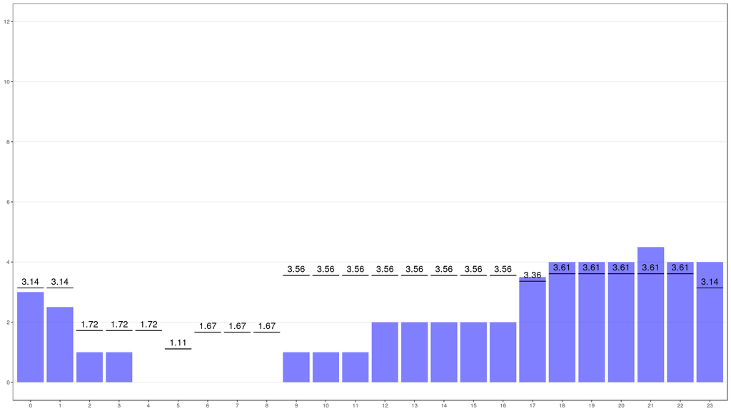

#### Total

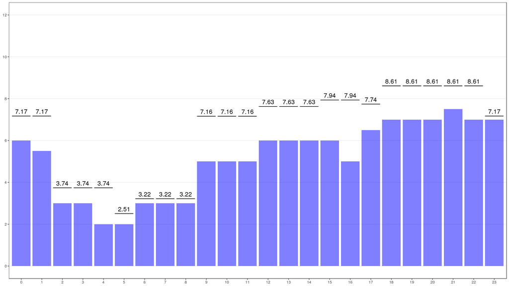